# Revisão de Álgebra Matricial

## Definição e propriedades básicas

- Uma matriz é um conjunto de números ou variáveis dispostos em linhas e colunas.
- Uma matriz $\mathbf{A}$ de $n$ linhas e $p$ colunas (dimensão $n \times p$) pode ser representada, genericamente, por:

$${\mathbf A} = \left[ \begin{array}{cccc} a_{11} & a_{12} & \cdots & a_{1p} \\ a_{21} & a_{22} & \cdots & a_{2p} \\ \vdots & \vdots & \ddots & \vdots \\
a_{n1} & a_{n2} & \cdots & a_{np} \end{array} \right]$$

- A matriz $\mathbf{A}$ pode ser denotada ainda por $\mathbf{A} = \{a_{ij}\}$, onde o primeiro índice indica linha, o segundo coluna e $a_{ij}$ é o termo geral da matriz.

## Definição e propriedades básicas

- Um vetor $\mathbf{x}$, de dimensão $n$, é representado, genericamente, por:

$$\mathbf{x} = \left[ \begin{array}{c} x_1 \\ x_2 \\ \vdots \\ x_n \end{array} \right]$$

- Numa análise multivariada com $n$ indivíduos e $p$ variáveis, as linhas da **matriz de dados** (observações dos indivíduos) podem ser consideradas $n$ vetores de dimensão $p$: $\mathbf{x}_i^t = (x_{i1}, x_{i2}, \cdots, x_{ip}), \,\,\,\,\, i = 1, 2, \cdots, n$;

## Definição e propriedades básicas

- As colunas da matriz de dados (observações referentes à variáveis) podem ser consideradas $p$ vetores de dimensão $n$:

$$\mathbf{x}_j^t = (x_{1j}, x_{2j}, \cdots, x_{nj}), \,\,\,\,\, j = 1, 2, \cdots, p$$

- A multiplicação de um vetor $\mathbf{x} = (x_1, x_2 , \cdots, x_p)^t$ por um escalar real $c$ resulta em um vetor $\mathbf{y} = c \mathbf{x} = (cx_1 , cx_2 , \cdots, cx_p)^t$, de igual dimensão em relação ao vetor original;
- Geometricamente, a multiplicação de um vetor por um escalar pode mudar seu tamanho e sentido, mas não sua direção.

## Definição e propriedades básicas

- A soma de dois vetores $\mathbf{x}$ e $\mathbf{y}$, de iguais dimensões, resulta em um terceiro vetor dado por:

$$\mathbf{z} = \mathbf{x} + \mathbf{y} = (x_1 + y_1, x_2 + y_2, \cdots, x_p + y_p)^t$$

- A diferença de dois vetores $\mathbf{x}$ e $\mathbf{y}$, de iguais dimensões, resulta em um terceiro vetor dado por:

$$\mathbf{w} = \mathbf{x} - \mathbf{y} = (x_1 - y_1, x_2 - y_2, \cdots, x_p - y_p)^t$$

## Definição e propriedades básicas

- O produto interno de dois vetores $\mathbf{x}$ e $\mathbf{y}$ é definido por:

$$\mathbf{v} = \mathbf{x}^t\mathbf{y} = \displaystyle{\sum_{i=1}^{p}} x_iy_i = x_1 y_1 + x_2 y_2 + \cdots + x_p y_p$$

- O tamanho do vetor $\mathbf{x} = (x_1, x_2, \cdots, x_p)^t$ é definido pela distância do ponto $p$-dimensional, determinado por suas coordenadas, à origem:

$$L_x = \sqrt{\mathbf{x}^t\mathbf{x}} = \sqrt{x_1^2 + x_2^2 + \cdots + x_p^2}$$

## Definição e propriedades básicas

- O cosseno do ângulo $\theta$ entre os vetores $\mathbf{x}$ e $\mathbf{y}$ definidos em $\mathbb{R}^p$ é dado por:

$$\cos({\theta}) = \dfrac{\mathbf{x}^t\mathbf{y}}{\sqrt{\mathbf{x}^t\mathbf{x}} \sqrt{\mathbf{y}^t\mathbf{y}}}$$

- Dois vetores $\mathbf{x}$ e $\mathbf{y}$ são entre si se o ângulo $\theta$ entre eles é $90^o$, de tal forma que $\cos(\theta) = 0$, ou, de forma equivalente, $\mathbf{x}^t\mathbf{y} = 0$.
- A **normalização** de um vetor $\mathbf{x}$ corresponde à divisão de $\mathbf{x}$ por $L_x$, de tal forma que o vetor resultante tenha comprimento unitário:

$$\mathbf{x}^* = \dfrac{\mathbf{x}}{L_x}$$

## Definição e propriedades básicas

- A **projeção** de um vetor $\mathbf{x}$ em um vetor $\mathbf{y}$ é um novo vetor, com coordenadas:

$$\text{Projeção de } \mathbf{x} \text{ em } \mathbf{y} = \dfrac{\mathbf{x}^t\mathbf{y}}{\mathbf{y}^t\mathbf{y}} \mathbf{y}$$

- O comprimento da projeção de $\mathbf{x}$ em $\mathbf{y}$ é dado por:

$$\text{Tamanho da projeção de } \mathbf{x} \text{ em } \mathbf{y} = \dfrac{|\mathbf{x}^t\mathbf{y}|}{L_y} = L_x \cos(\theta)$$

## Definição e propriedades básicas

- **Igualdade de matrizes:** Dizemos que duas matrizes $\mathbf{A}$ e $\mathbf{B}$ são iguais se elas tem iguais dimensões e $\{a_{ij}\} = \{b_{ij}\}$ para todo $i$ e para todo $j$.
- **Matriz transposta:** A transposta de uma matriz $\mathbf{A}_{n \times p}$ é a matriz $\mathbf{A}^t_{p \times n}$ tal que $\{a_{ij}\} = \{a_{ji}\}$ para todo $i$ e para todo $j$:

$$\mathbf{A}^t = \left[ \begin{array}{cccc} a_{11} & a_{21} & \cdots & a_{n1} \\ a_{12} & a_{22} & \cdots & a_{n2} \\ \vdots & \vdots & \ddots & \vdots \\
a_{1p} & a_{2p} & \cdots & a_{np} \end{array} \right]$$

## Definição e propriedades básicas

- **Matriz simétrica:** Dizemos que uma matriz $\mathbf{A}_{p \times p}$ é simétrica se $\{a_{ij}\} = \{a_{ji}\}$ para todo $i$ e para todo $j$, ou seja, $\mathbf{A}^t = \mathbf{A}$.
- **Diagonal de uma matriz:** A diagonal de uma matriz quadrada $\mathbf{A}_{p \times p}$ corresponde ao conjunto de elementos $a_{11}, a_{22}, \cdots, a_{pp}$.
- **Matriz diagonal:** Dizemos que a matriz quadrada $\mathbf{A}_{p \times p}$ é diagonal se todos os elementos fora da diagonal são iguais a zero:

$$\mathbf{A} = \left[ \begin{array}{cccc} a_{11} & 0 & \cdots & 0 \\ 0 & a_{22} & \cdots & 0 \\ \vdots & \vdots & \ddots & \vdots \\
0 & 0 & \cdots & a_{pp} \end{array} \right]$$

## Definição e propriedades básicas

- **Matriz identidade:** Dizemos que a matriz quadrada $\mathbf{I}_{p\times p}$ é uma matriz identidade se ela é uma matriz diagonal com todos os elementos da diagonal iguais a 1:

$$\mathbf{I} = \left[ \begin{array}{cccc} 1 & 0 & \cdots & 0 \\ 0 & 1 & \cdots & 0 \\ \vdots & \vdots & \ddots & \vdots \\
0 & 0 & \cdots & 1 \end{array} \right]$$

## Definição e propriedades básicas

- **Matriz triangular superior:** Dizemos que a matriz quadrada $\mathbf{A}_{p \times p}$ é uma matriz triangular superior se todos os elementos abaixo da diagonal são iguais a zero:

$$\mathbf{A} = \left[ \begin{array}{cccc} a_{11} & a_{12} & \cdots & a_{1p} \\ 0 & a_{22} & \cdots & a_{2p} \\ \vdots & \vdots & \ddots & \vdots \\
0 & 0 & \cdots & a_{pp} \end{array} \right]$$

- Uma **matriz triangular inferior** é definida de forma semelhante.

## Operações envolvendo matrizes

- A **soma** de duas matrizes $\mathbf{A}_{n \times p}$ e $\mathbf{B}_{n \times p}$ de **iguais dimensões** é a matriz resultante das somas dos elementos nas posições correspondentes:

$$\mathbf{A} + \mathbf{B} = \left[ \begin{array}{cccc} a_{11} + b_{11} & a_{12} + b_{12} & \cdots & a_{1p} + b_{1p}\\ a_{21} + b_{21}& a_{22} + b_{22}& \cdots & a_{2p} + b_{2p} \\ \vdots & \vdots & \ddots & \vdots \\
a_{n1} + b_{n1} & a_{n2} + b_{n2} & \cdots & a_{np} + b_{np} \end{array} \right]$$

## Operações envolvendo matrizes

- A **diferença** de duas matrizes $\mathbf{A}_{n \times p}$ e $\mathbf{B}_{n \times p}$ de **iguais dimensões** é a matriz resultante das diferenças dos elementos nas posições correspondentes:

$$\mathbf{A} - \mathbf{B} = \left[ \begin{array}{cccc} a_{11} - b_{11} & a_{12} - b_{12} & \cdots & a_{1p} - b_{1p}\\ a_{21} - b_{21}& a_{22} - b_{22}& \cdots & a_{2p} - b_{2p} \\ \vdots & \vdots & \ddots & \vdots \\ a_{n1} - b_{n1} & a_{n2} - b_{n2} & \cdots & a_{np} - b_{np} \end{array} \right]$$

## Operações envolvendo matrizes

- Sejam $\mathbf{A}_{n \times k}$ e $\mathbf{B}_{k \times p}$ duas matrizes, tais que o número de linhas da segunda é igual ao número de colunas da primeira. O **produto** $\mathbf{AB}$ é definido por:

$$\mathbf{A} \mathbf{B} = \left[ \begin{array}{cccc} \sum_{r = 1}^k a_{1r}. b_{r1} & \sum_{r = 1}^k a_{1r}. b_{r2} & \cdots & \sum_{r = 1}^k a_{1r}. b_{rp}\\ \sum_{r = 1}^k a_{2r}. b_{r1} & \sum_{r = 1}^k a_{2r}. b_{r2} & \cdots & \sum_{r = 1}^k a_{2r}. b_{rp} \\ \vdots & \vdots & \ddots & \vdots \\
\sum_{r = 1}^k a_{nr}. b_{r1} & \sum_{r = 1}^k a_{nr}. b_{r2} & \cdots & \sum_{r = 1}^k a_{nr}. b_{rp} \end{array} \right]$$

- Dizemos que uma matriz quadrada $\mathbf{Q}$ é **ortogonal** se $\mathbf{QQ}^t = \mathbf{Q}^t \mathbf{Q} = \mathbf{I}$.

## Operações envolvendo matrizes

- Sejam $\mathbf{A}_{n \times p}$ e $c$ uma constante. O produto $c \mathbf{A}$ resulta no produto de cada elemento de $\mathbf{A}$ por $c$:

$$c\mathbf{A} = \left[ \begin{array}{cccc} ca_{11} & ca_{12} & \cdots & ca_{1p} \\ ca_{21} & ca_{22} & \cdots & ca_{2p} \\ \vdots & \vdots & \ddots & \vdots \\
ca_{n1} & ca_{n2} & \cdots & ca_{np} \end{array} \right]$$

## Operações envolvendo matrizes

- Sejam $\mathbf{A}$, $\mathbf{B}$ e $\mathbf{C}$ matrizes com dimensões compatíveis para as operações consideradas. Então:
  - $(\mathbf{A}^t)^t = \mathbf{A}$;
  - $\mathbf{A} + \mathbf{B} = \mathbf{B} + \mathbf{A}$;
  - $(\mathbf{A} + \mathbf{B})^t = \mathbf{A}^t + \mathbf{B}^t$;
  - $(\mathbf{A} - \mathbf{B})^t = \mathbf{A}^t - \mathbf{B}^t$;
  - $(\mathbf{AB})^t = \mathbf{B}^t \mathbf{A}^t$;
  - $\mathbf{AB} \neq \mathbf{BA}$, a menos de situações bem específicas;

## Operações envolvendo matrizes

- Sejam $\mathbf{A}$, $\mathbf{B}$ e $\mathbf{C}$ matrizes com dimensões compatíveis para as operações consideradas. Então:
  - $\mathbf{A}(\mathbf{B} + \mathbf{C}) = \mathbf{AB} + \mathbf{AC}$, valendo o mesmo ao substituir a soma pela diferença;
  - $(\mathbf{A} + \mathbf{B}) \mathbf{C} = \mathbf{AC} + \mathbf{BC}$, valendo o mesmo ao substituir a soma pela diferença;
  - $(\mathbf{A} + \mathbf{B})\mathbf{C} \neq \mathbf{CA} + \mathbf{CB}$, a menos de situações bem específicas;
  - $\mathbf{IA} = \mathbf{AI} = \mathbf{A}$, para qualquer $\mathbf{A}$.

## Operações envolvendo matrizes

- O **traço** de uma matriz de uma matriz $\mathbf{A}_{p \times p}$, denotado por $\text{tr}(\mathbf{A})$, corresponde à soma dos elementos da diagonal de $\mathbf{A}$:

$$\text{tr}(\mathbf{A}) = \displaystyle{\sum_{i=1}^{p}a_{ii}}$$

- Sejam $\mathbf{A}$ e $\mathbf{B}$ matrizes quadradas. Então:
  - $\text{tr}(\mathbf{A} + \mathbf{B}) = \text{tr}(\mathbf{A}) + \text{tr}(\mathbf{B})$
  - $\text{tr}(\mathbf{A} \mathbf{B}) = \text{tr}(\mathbf{B} \mathbf{A})$

## Combinações lineares e formas quadráticas

- Para um conjunto de constantes $a_1, a_2, \cdots, a_p$, o vetor $\mathbf{y} = a_1 \mathbf{x}_1 + a_2 \mathbf{x}_ 2 + \cdots + a_p \mathbf{x}_p$ é uma **combinação linear** dos vetores $\mathbf{x}_1, \mathbf{x}_2, \cdots, \mathbf{x}_p$ .
- O conjunto de vetores $\mathbf{x}_1, \mathbf{x}_2, \cdots, \mathbf{x}_p$ é dito **linearmente dependente** se há um conjunto de constantes $a_1, a_2, \cdots, a_p$, **nem todas nulas**, tal que:

$$a_1 \mathbf{x}_1 + a_2 \mathbf{x}_ 2 + \cdots + a_p \mathbf{x}_p = 0$$

- Caso contrário os vetores são **linearmente independentes**.

## Combinações lineares e formas quadráticas

- **Formas quadráticas** surgem de forma recorrente na estatística multivariada, por exemplo, na definição de distâncias.
- Uma **forma quadrática**, definida a partir de uma matriz simétrica $\mathbf{A}_{p \times p}$, é definida como:

$$Q(\mathbf{x}) = {\mathbf{x}^t} \mathbf{A} \mathbf{x} =\displaystyle{\sum_{i=1}^p a_{ii} x_{i}^2} + 2 \displaystyle{\sum_{i = 1}^{p-1}} \displaystyle{\sum_{k = i+1}^{p}} a_{ik} x_i x_k = \displaystyle{\sum_{i=1}^p} \displaystyle{\sum_{k=1}^p} a_{ik} x_i x_k$$

para $\mathbf{x} \neq \mathbf{0}$ definido em $\mathbb{R}^p$.

## Combinações lineares e formas quadráticas

- Classificamos a matriz $\mathbf{A}$, e a consequente forma quadrática $\mathbf{x}^t \mathbf{A}\mathbf{x}$, como **positiva definida** se $Q(\mathbf{x}) > 0$ para qualquer $\mathbf{x} \neq \mathbf{0}$.
- Outras classificações:
  - **Positiva semidefinida:** $Q(\mathbf{x}) \geqslant 0$
  - **Negativa definida:** $Q(\mathbf{x}) < 0$
  - **Negativa semidefinida:** $Q(\mathbf{x}) \leqslant 0$
  - **Indefinida:** $Q(\mathbf{x}) > 0$ para alguns $\mathbf{x} \in \mathbb{R}^p$ e $Q(\mathbf{x}) < 0$ para outros $\mathbf{x} \in \mathbb{R}^p$

## Matriz inversa

- **Matriz inversa:** Considere uma matriz $\mathbf{A}_{p \times p}$. Caso exista uma matriz $\mathbf{B}_{p \times p}$ tal que

$$\mathbf{AB} = \mathbf{BA} = \mathbf{I}$$

dizemos que $\mathbf{B}$ é a matriz inversa de $\mathbf{A}$, sendo usualmente denotada por $\mathbf{A}^{-1}$.

- Quando uma matriz possui uma matriz inversa, dizemos que ela é **não-singular**. Caso contrário, ela é classificada como **singular**.

## Matriz inversa

- A condição fundamental para que uma matriz tenha inversa é que suas colunas sejam linearmente independentes (matriz de $rank$ completo).
- O $rank$ de uma matriz $\mathbf{A}_{n \times p}$ , denotado por $rank(\mathbf{A})$, é definido como o número de linhas (ou colunas) linearmente independentes de $\mathbf{A}$.
- Dizemos que a matriz quadrada $\mathbf{A}_{p \times p}$ tem $rank$ completo se $rank(\mathbf{A}) = p$, configurando uma matriz não singular.
- Para matrizes de $rank$ incompleto ou não-quadradas, define-se a inversa generalizada de $\mathbf{A}$ como a matriz $\mathbf{A}^-$ que satisfaz $\mathbf{A} \mathbf{A}^- \mathbf{A} = \mathbf{A}$.

## Matriz inversa

- A inversa de uma matriz diagonal é dada pela matriz diagonal composta pelos inversos dos elementos da matriz original:

$$\mathbf{A} = \left[ \begin{array}{cccc} a_{11} & 0 & \cdots & 0 \\ 0 & a_{22} & \cdots & 0 \\ \vdots & \vdots & \ddots & \vdots \\
0 & 0 & \cdots & a_{pp} \end{array} \right]; \,\,\,\,\,\,\,\,\, \mathbf{A}^{-1} = \left[ \begin{array}{cccc} \frac{1}{a_{11}} & 0 & \cdots & 0 \\ 0 & \frac{1}{a_{22}} & \cdots & 0 \\ \vdots & \vdots & \ddots & \vdots \\ 0 & 0 & \cdots & \frac{1}{a_{pp}} \end{array} \right]$$

## Matriz inversa

- $\mathbf{A}$ e $\mathbf{B}$ não singulares $(p \times p)$, $(\mathbf{AB})^{-1} = \mathbf{B}^{-1} \mathbf{A}^{-1}$;
- Para $c$ uma constante real diferente de zero, $(c \mathbf{B})^{-1} = c^{-1}(\mathbf{A})^{-1}$;
- $(\mathbf{A}^t)^{-1} = (\mathbf{A}^{-1})^t$;
- Se $rank(\mathbf{A}) = p$ então $\mathbf{A}^{-1}$ existe;
- Se $\mathbf{A}$ é ortogonal, então $\mathbf{A}^{-1}$ existe, além do que $\mathbf{A}^{-1} = \mathbf{A}^t$;
- Se $\mathbf{B}$ é não singular, $\mathbf{AB} = \mathbf{CB}$ implica $\mathbf{A} = \mathbf{C}$.

## Determinante

- O **determinante** de uma matriz $\mathbf{A}_{p \times p}$ , denotado por $\det(\mathbf{A})$ ou $|\mathbf{A}|$, é definido como:

  $$\det(\mathbf{A}) = \begin{cases} a_{11} & \text{ se } p = 1 \\ \sum \limits_{j=1}^p a_{ij} |\mathbf{A}_{ij}| (-1)^{i+j} & \text{ se } p > 1\end{cases}$$

sendo $\mathbf{A}_{ij}$ a matriz $(p - 1) \times (p - 1)$ resultante da exclusão da $i$-ésima linha e $j$-ésima coluna de $\mathbf{A}$.

## Determinante

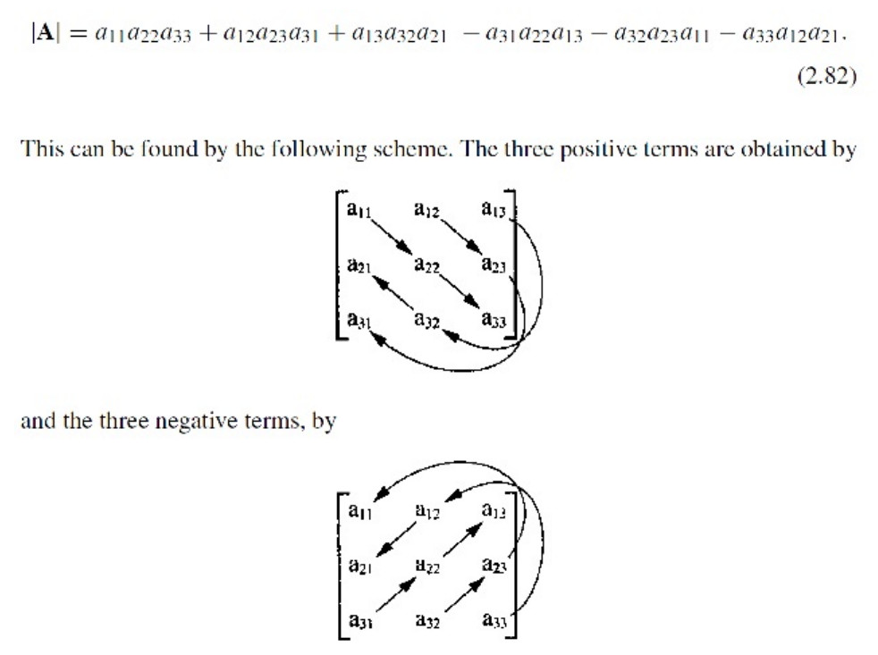

## Determinante

- Sejam as matrizes $\mathbf{A}$ e $\mathbf{B}$ quadradas de ordem $p$ e seja $c$ um escalar. Então,
  - $\left|c \mathbf{A}\right| = c^p \left| \mathbf{A} \right|$;
  - $\left|\mathbf{A}^t \right| = \left|\mathbf{A}\right|$;
  - $\left|\mathbf{A}^{-1} \right| = \displaystyle{\dfrac {1}{\left|\mathbf{A}\right|}} = \left|\mathbf{A}\right|^{-1}$;
  - Se $rank(\mathbf{A}) < p$ então $|\mathbf{A}| = 0$;
  - Se $rank(\mathbf{A}) = p$ então $|\mathbf{A}| \neq 0$;

## Determinante

- Sejam as matrizes $\mathbf{A}$ e $\mathbf{B}$ quadradas de ordem $p$ e seja $c$ um escalar. Então,
  - $\left| \mathbf{AB} \right| = \left|\mathbf{A}\right| \left|\mathbf{B}\right|$;
  - $\left| \mathbf{ABA}^{-1} \right| = \left|\mathbf{A}\right| \left|\mathbf{B}\right| \left|\mathbf{A}^{-1}\right|$;
  - Se $\mathbf{A}$ é uma matriz diagonal, então $|\mathbf{A}| = \displaystyle{\prod_{i=1}^p a_{ii}}$;
  - Se uma matriz $\mathbf{A}$ é singular, então $\left| \mathbf{A} \right| = 0$;
  - Se uma matriz $\mathbf{A}$ é não-singular, então $\left| \mathbf{A} \right| \neq 0$;
  - Se uma matriz $\mathbf{A}$ é positiva definida, então $\left| \mathbf{A} \right| > 0$.

## Autovalores e autovetores

- Seja $\mathbf{A}$ uma matriz quadrada e $\mathbf{I}$ a matriz identidade, ambas $p \times p$. Os escalares $\lambda_1, \lambda_2, \cdots, \lambda_p$ que são a solução da equação polinomial $|\mathbf{A} - \lambda \mathbf{I}| = 0$ são chamados **autovalores** (ou valores característicos) de $\mathbf{A}$.
- A equação $|\mathbf{A} - \lambda \mathbf{I}| = 0$ (como função de $\lambda$) é chamada **equação característica**.
- Seja $\mathbf{A}$ uma matriz quadrada $p \times p$ e $\lambda$ um autovalor de $\mathbf{A}$. Então, o vetor $\mathbf{x}$ $(p \times 1)$, não nulo, que satisfaz:

$$\mathbf{Ax} = \lambda \mathbf{x}$$

é chamado **autovetor** (ou vetor característico) de $\mathbf{A}$ associado ao autovalor $\lambda$.

## Autovalores e autovetores

- Para qualquer matriz simétrica $\mathbf{A}$ com autovalores $\lambda_1, \lambda_2, \cdots, \lambda_p$, valem:

$$\text{tr}(\mathbf{A}) = \displaystyle{\sum_{i=1}^{p}\lambda_{i}} \hspace{1cm} \text{e} \hspace{1cm} \left|\mathbf{A} \right| = \displaystyle{\prod_{i=1}^{p}\lambda_{i}}$$

- Se todos os autovalores da matriz $\mathbf{A}$ são positivos maiores que zero, então a matriz $\mathbf{A}$ é positiva definida;
- Se os autovalores da matriz $\mathbf{A}$ são positivos ou iguais a zero, então a matriz $\mathbf{A}$ é positiva semidefinida. Neste caso, o número de autovalores positivos será igual ao posto da matriz $\mathbf{A}$
- Os autovetores de uma matriz $\mathbf{A}$ simétrica de dimensão $p \times p$ são ortogonais.

## Teorema da decomposição espectral

- Como resultado da ortogonalidade dos autovetores de $\mathbf{A}$ tem-se o **Teorema da Decomposição Espectral**.
- Toda matriz simétrica $\mathbf{A}$ de ordem $p \times p$ pode ser decomposta em:

$$\mathbf{A} = \mathbf{C} \mathbf{\Lambda} \mathbf{C}^t = \displaystyle{\sum_{i = 1}^p \lambda_i {\mathbf{e}_i \mathbf{e}_i^t}}$$

## Teorema da decomposição espectral

em que $\mathbf{\Lambda}$ é a matriz diagonal dos autovalores:

$$\mathbf{\Lambda} = \left[ \begin{array}{cccc} \lambda_1 & 0 & \cdots & 0 \\ 0 & \lambda_2 & \cdots & 0 \\ \vdots & \vdots & \ddots & \vdots \\ 0 & 0 & \cdots & \lambda_p \end{array} \right]$$

e $\mathbf{C}$ é a matriz ortogonal com os autovetores normalizados de $\mathbf{A}$ nas colunas:

$$\mathbf{C} = \left[\begin{array}{rrrr} \mathbf{e}_1 & \mathbf{e}_2 & \cdots & \mathbf{e}_p \end{array} \right]$$